# R Notebook

```r
library("knitr")
opts_chunk$set(cache = TRUE, message = FALSE, warning = FALSE)

library(tidyverse)
library(data.table)
library(useful)
library(biomaRt)
library(ggrepel)
library(ggthemes)
library(magrittr)
library(DESeq2)
library(cowplot)
library(pheatmap)
library(broom)
library(openxlsx)
```

# QC

```r
qc.df <- readRDS("../data/qc_df.rds")
```

# Init data

## BiomaRt

```r
ensembl.map <- readRDS("../data/biomart_enmsebl_map.rds")
```

## metadata

D12 was an outlier by QC standards (low read depth, low alignment to genome)

```r
metadata <- read.xlsx("../data/Raychaudhuri_PlateMap_Final.xlsx") %>%
  tidyr::separate(Sample.Identifier, c("donor", "cell"), sep = ":") %>%
  dplyr::select(Position, donor, cell) %>%
  dplyr::left_join(
    rbind(
      data.frame(donor = unlist(strsplit("10040772,10038559,10043467,10043449,28778769,10030474", split = ",")), status = "oa", stringsAsFactors = F),
      data.frame(donor = unlist(strsplit("10029276,10024302,10018377,10029272,10024301,10008438,10024253", split = ",")), status = "ra", stringsAsFactors = F)
    )
  )
row.names(metadata) <- metadata$Position

dds.coldata <- metadata#[samples.use, , drop = F]
dds.coldata$cell <- gsub("\\+", "p", dds.coldata$cell)
dds.coldata$cell <- gsub("-", "n", dds.coldata$cell)
```

## expression

```r
exprs.kallisto <- readRDS("../data/exprs_kallisto.rds")
```

# Filter

## Samples

Remove empty cells and outliers (D12).

```r
samples.keep <- subset(metadata, Position != "D12" & cell != "Empty")$Position
exprs.kallisto %<>% dplyr::filter(Position %in% samples.keep)
# exprs.rsem %<>% dplyr::filter(Position %in% samples.keep)

# length(unique(exprs.kallisto$Position)); length(unique(exprs.rsem$Position))
```

## Genes

```r
genes.expressed.kallisto <- data.table(exprs.kallisto)[est_counts > 5, .N, by = hgnc_symbol][N > 10, hgnc_symbol]
# genes.expressed.rsem <- data.table(exprs.rsem)[expected_count > 5, .N, by = hgnc_symbol][N > 10, hgnc_symbol]
# genes.expressed <- intersect(genes.expressed.kallisto, genes.expressed.rsem)
# length(genes.expressed.kallisto); length(genes.expressed.rsem); length(genes.expressed)

length(genes.expressed.kallisto); length(unique(exprs.kallisto$hgnc_symbol))
```

```
## [1] 15234
```

```
## [1] 27717
```

```r
exprs.kallisto.filtered <- dplyr::filter(exprs.kallisto, hgnc_symbol %in% genes.expressed.kallisto)
# exprs.rsem %<>% dplyr::filter(hgnc_symbol %in% genes.expressed)
```

# Normalize

```r
exprs.kallisto.counts <- exprs.kallisto.filtered %>%
  dplyr::select(Position, hgnc_symbol, est_counts) %>%
  tidyr::spread(Position, est_counts) %>%
  data.frame

row.names(exprs.kallisto.counts) <- exprs.kallisto.counts$hgnc_symbol
exprs.kallisto.counts$hgnc_symbol <- NULL

dds.kallisto <- DESeqDataSetFromMatrix(countData = round(exprs.kallisto.counts),
                              colData = dds.coldata[colnames(exprs.kallisto.counts), ],
                              design = ~cell)
dds.kallisto <- DESeq2::estimateSizeFactors(dds.kallisto)
dds.kallisto <- DESeq2::estimateDispersions(dds.kallisto)
exprs.kallisto.counts <- DESeq2::getVarianceStabilizedData(dds.kallisto)

# exprs.kallisto.counts <- log2(1 + exprs.kallisto.counts)
```

# PCA

```r
pca.res.kallisto.counts <- prcomp(exprs.kallisto.counts)$rotation[, 1:2] %>%
  data.frame %>% tibble::rownames_to_column("Position") %>%
  dplyr::mutate(type = "kallisto.counts")
# pca.res.kallisto.tpm <- prcomp( exprs.kallisto.tpm)$rotation[, 1:2] %>%
#   data.frame %>% tibble::rownames_to_column("Position") %>%
#   dplyr::mutate(type = "kallisto.tpm")
# pca.res.rsem.counts <- prcomp(exprs.rsem.counts)$rotation[, 1:2] %>%
#   data.frame %>% tibble::rownames_to_column("Position") %>%
#   dplyr::mutate(type = "rsem.counts")
# pca.res.rsem.tpm <- prcomp(exprs.rsem.tpm)$rotation[, 1:2] %>%
#   data.frame %>% tibble::rownames_to_column("Position") %>%
#   dplyr::mutate(type = "rsem.tpm")
#
# pca.res.all <- do.call(rbind, list(pca.res.rsem.tpm, pca.res.kallisto.tpm,
#                                    pca.res.rsem.counts, pca.res.kallisto.counts))
```

## PC2 varies with cell type

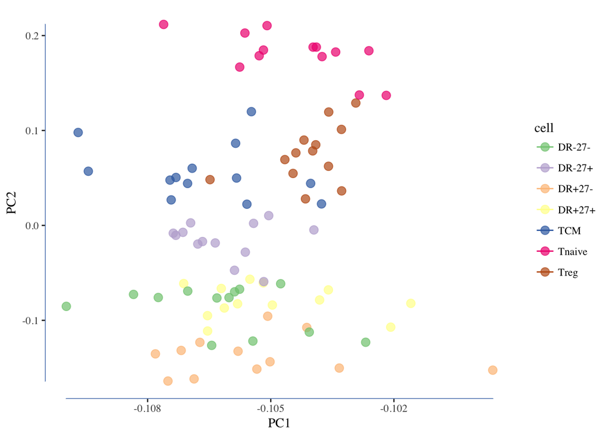

```r
# pca.res.all %>%
#   dplyr::inner_join(metadata) %>%
#   ggplot(aes(PC1, PC2, col = cell)) + geom_point(size = 3, alpha = .7) +
#     scale_color_brewer(type = "qual") +
#     geom_rangeframe() + theme_tufte() +
#     theme(plot.title = element_text(hjust = 0.5, size = 16)) +
#     facet_wrap(~type, scales = "free")

pca.res.kallisto.counts %>%
  dplyr::inner_join(metadata) %>%
  ggplot(aes(PC1, PC2, col = cell)) + geom_point(size = 3, alpha = .7) +
    scale_color_brewer(type = "qual") +
    geom_rangeframe() + theme_tufte() +
    theme(plot.title = element_text(hjust = 0.5, size = 16))
```

For downstream analyses, define the groups as ordered by PC2. Note that for TCM/Treg and DR+27+/DR-27-, the ordering is partial.

```r
cell.levels <- c("Tnaive", "Treg", "TCM", "DR-27+", "DR+27+", "DR-27-", "DR+27-")
```

## PC gene loadings

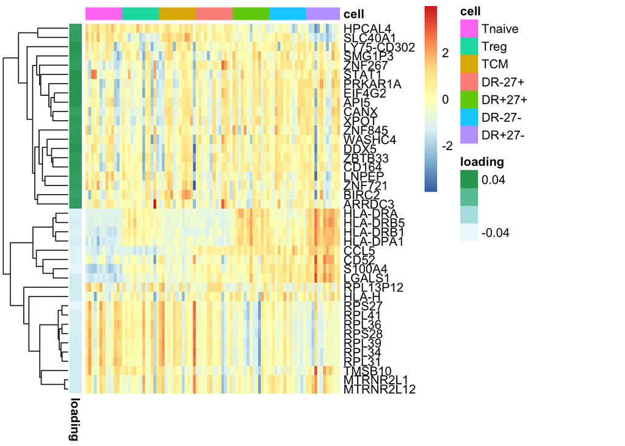

```r
loadings.pc2 <- prcomp(t(exprs.kallisto.counts))$rotation[, 2]
genes.pc2 <- c(head(loadings.pc2[order(loadings.pc2)], 20), tail(loadings.pc2[order(loadings.pc2)], 20))

anno.col.df <- metadata %>%
  dplyr::filter(Position %in% colnames(exprs.kallisto.counts)) %>%
  dplyr::mutate(cell = factor(cell, levels = cell.levels)) %>%
  dplyr::arrange(cell)
row.names(anno.col.df) <- anno.col.df$Position

exprs.kallisto.counts[names(genes.pc2), anno.col.df$Position] %>%
  pheatmap(labels_col = rep("", 90),
           annotation_col = anno.col.df[, "cell", drop = F],
           annotation_row = data.frame(loading = genes.pc2),
           cluster_cols = F, cluster_rows = T, scale = "row")
```

## What does PC1 explain?

```r
x <- pca.res.kallisto.counts %>%
  # dplyr::filter(type == "kallisto.counts") %>%
  dplyr::inner_join(qc.df) %>%
  dplyr::inner_join(metadata)

tmp <- dplyr::select(x, Position, PC1, TOTAL_READS:ESTIMATED_LIBRARY_SIZE) %>%
  tidyr::gather(key, val, -Position, -PC1)
data.table(tmp)[, tidy(cor.test(~ val + PC1, .SD)), by = key][
  , q.value := p.adjust(p.value)
][order(q.value), .(key, estimate, sprintf("%.8f", q.value))]
```

```
##                       key   estimate         V3
## 1:   PCT_PF_READS_ALIGNED -0.6409213 0.00000000
## 2:   PCT_INTERGENIC_BASES  0.5981913 0.00000000
## 3:     PCT_INTRONIC_BASES  0.5362095 0.00000036
## 4:    PERCENT_DUPLICATION -0.4521757 0.00004605
## 5:    PCT_RIBOSOMAL_BASES -0.3873287 0.00081137
## 6:       PCT_CODING_BASES -0.2514488 0.06727360
## 7:            TOTAL_READS -0.1480687 0.27394300
## 8:          PCT_UTR_BASES -0.1697450 0.27394300
## 9: ESTIMATED_LIBRARY_SIZE  0.1790455 0.27394300
```

```r
data.table(tmp)[, tidy(cor.test(~ val + PC1, .SD)), by = key][
  , q.value := p.adjust(p.value)
][order(q.value)] %>% with(as.integer(-log10(q.value)))
```

```
## [1] 10  8  6  4  3  1  0  0  0
```

As a sanity check, visualize one of these relationships:

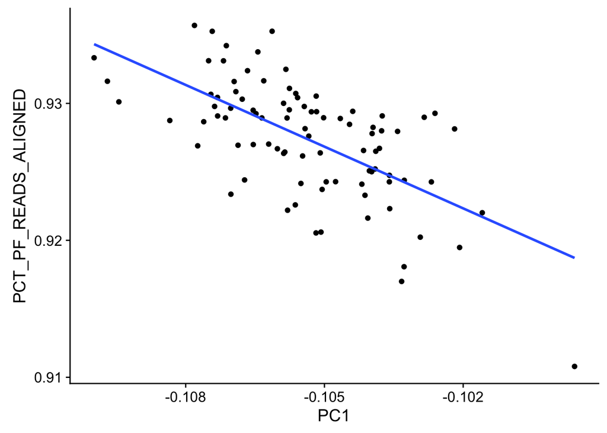

```r
x %>% ggplot(aes(PC1, PCT_PF_READS_ALIGNED)) + geom_point() + geom_smooth(method = lm, se = F)
```

# Differential Expression

Limma, use disease status as covariate. Highlight expression of markers across groups (like I did for Deepak)

*todo* Effect of including RA/OA status as covariate (plot coefficients against each other)

## LIMMA

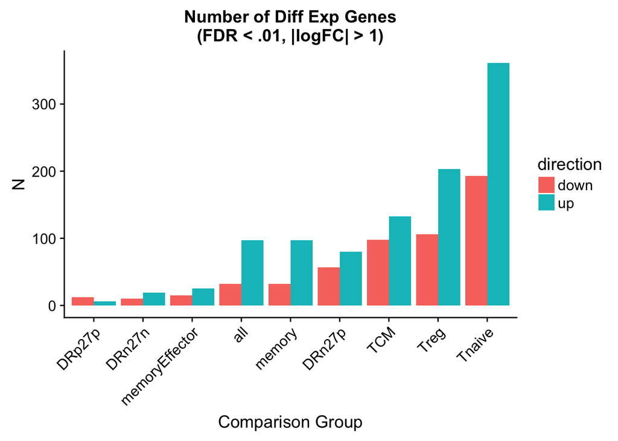

```r
data.table(limma.res.all)[
  , direction := ifelse(logFC > 0, "up", "down")
][
  abs(logFC) > 1 & adj.P.Val < .01
][
  , .N, by = .(direction, other.group)
] %>%
  ggplot(aes(reorder(other.group, N), N, fill = direction)) +
    geom_bar(stat = "identity", position = "dodge") +
    theme(axis.text.x = element_text(angle = 45, hjust = 1)) +
    labs(title = "Number of Diff Exp Genes\n(FDR < .01, |logFC| > 1)",
         x = "Comparison Group")
```

## DESeq2

# Markers

For consistency, we will order the cell types by PC2.

## Pre-specified

We replaced CRTH2 with PTGDR2, and PRF with PRF1

```r
markers <- list()
markers$`transcription factors` <- unlist(strsplit("TBX21,RORC,GATA3,FOXP3,IKZF2,BCL6,PRDM1,MAF", split = ","))
markers$`cytokines` <- unlist(strsplit("IFNG,IL4,IL5,IL13,IL17A,IL17F,TNF,IL2,IL10", split = ","))
markers$`killer molecules` <- unlist(strsplit("GZMA,GZMB,PRF1,GZMK,GNLY,NKG7", split = ","))
markers$`chemokine receptors` <- unlist(strsplit("CXCR3,CCR4,CCR6,CCR2,PTGDR2", split = ","))
```

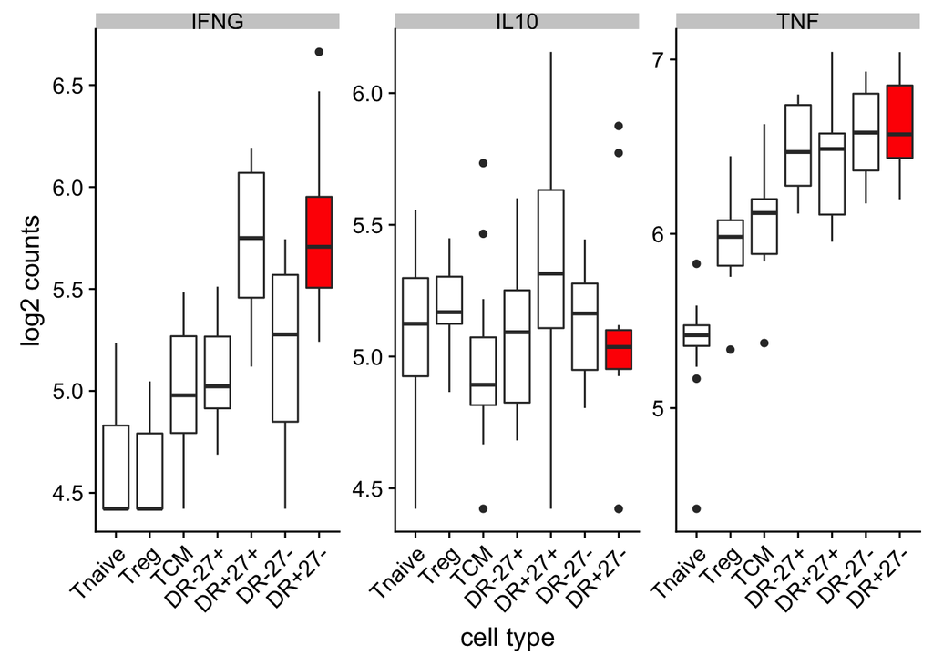

```r
plot.markers <- function(exprs.df, markers.use) {
  markers.use %<>% intersect(row.names(exprs.df))

  exprs.df <- exprs.df[markers.use, ] %>%
    data.frame %>%
    tibble::rownames_to_column("symbol") %>%
    tidyr::gather(Position, value, -symbol) %>%
    dplyr::inner_join(metadata) %>%
    dplyr::mutate(cell = factor(cell, levels = cell.levels))

  exprs.df %>%
    dplyr::filter(cell != "Empty") %>%
    ggplot(aes(cell, value, fill = cell == "DR+27-")) +
      geom_boxplot(position = position_dodge(1)) +
      facet_wrap(~symbol, scales = "free_y") +
      theme(axis.text.x = element_text(angle = 45, hjust = 1)) +
      scale_fill_manual(values = c("white", "red")) +
      guides(fill = FALSE, col = FALSE) +
      labs(y = "log2 counts", x = "cell type")
}

plot.markers(exprs.kallisto.counts, markers$cytokines)
```

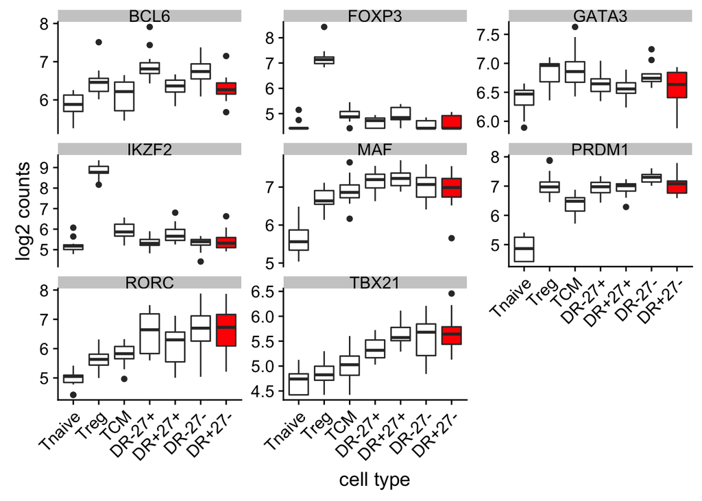

```r
plot.markers(exprs.kallisto.counts, markers$`transcription factors`)
```

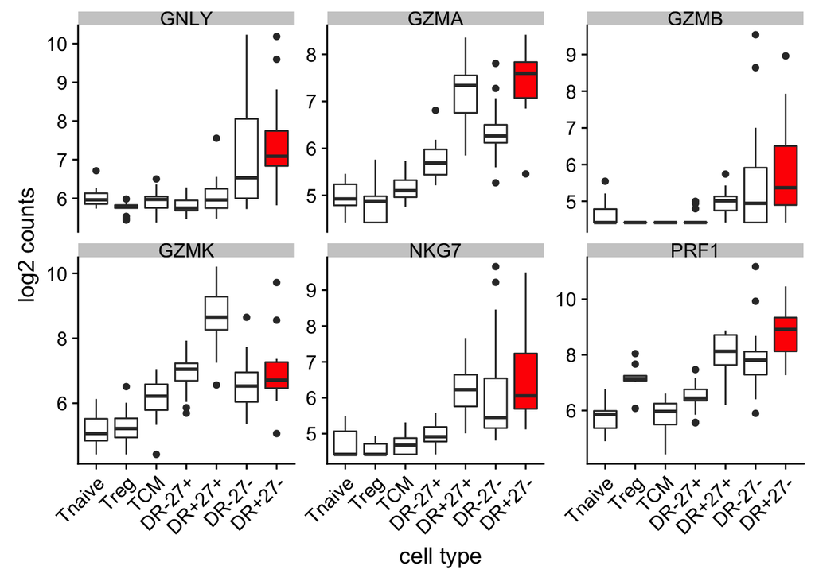

```r
plot.markers(exprs.kallisto.counts, markers$`killer molecules`)
```

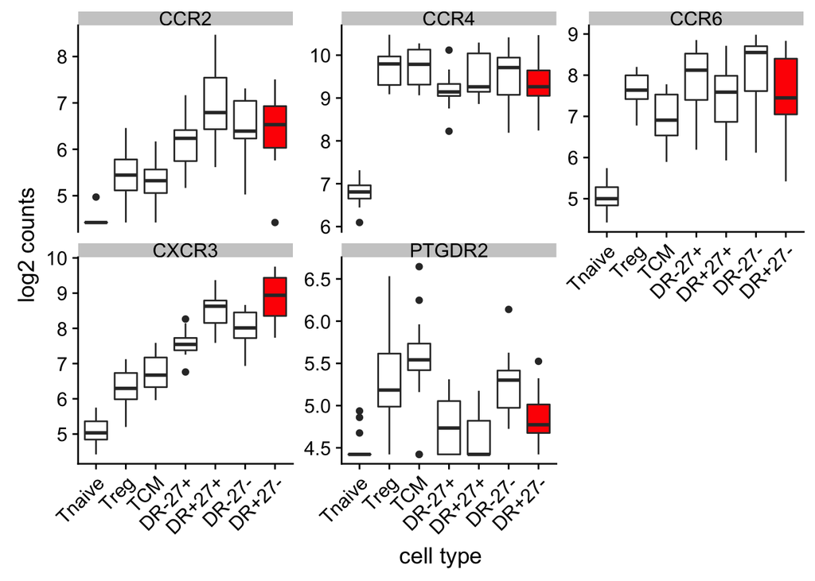

```r
plot.markers(exprs.kallisto.counts, markers$`chemokine receptors`)
```

## Unbiased

Let’s find unique positive markers for DR+27-. I filtered on FDR < 5% and FC > 1.5

```r
markers.unbiased <- data.table(limma.res.all)[adj.P.Val < .05 & logFC > log2(1.5), .N, by = .(feature)][N == 9, feature]
length(markers.unbiased)
```

```
## [1] 13
```

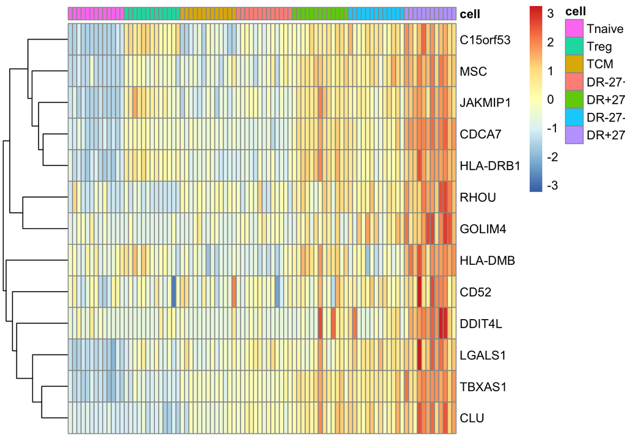

```r
anno.col.df <- metadata %>%
  dplyr::filter(Position %in% colnames(exprs.kallisto.counts)) %>%
  dplyr::mutate(cell = factor(cell, levels = cell.levels)) %>%
  dplyr::arrange(cell)
row.names(anno.col.df) <- anno.col.df$Position


exprs.kallisto.counts[markers.unbiased, anno.col.df$Position, drop = F] %>%
  pheatmap(labels_col = rep("", 90),
           annotation_col = anno.col.df[, "cell", drop = F],
           cluster_cols = F, cluster_rows = T, scale = "row")
```

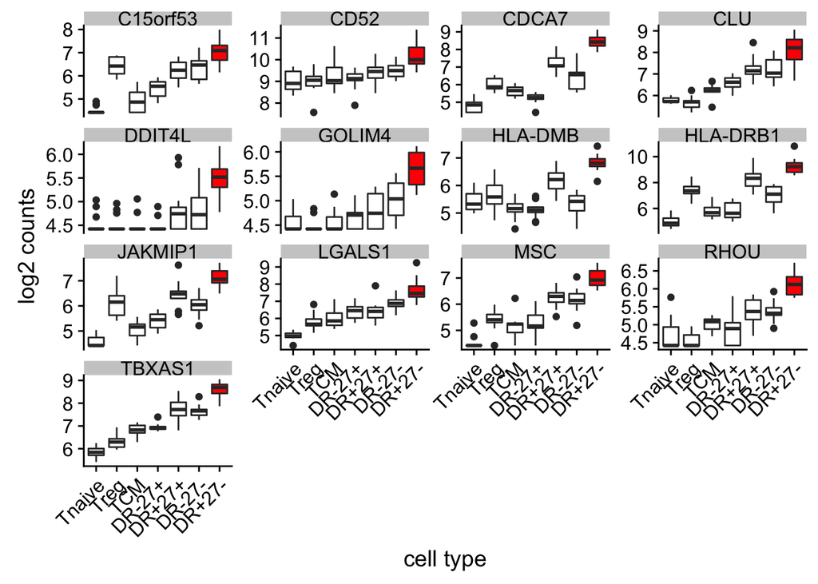

```r
plot.markers(exprs.kallisto.counts, markers.unbiased)
```

# Pathways

```r
library(gage)
do.gage <- function(top.table, genesets, rank.col, q.val.thresh = 1, gs.size.min = 10, gs.size.max = 500) {
  library(gage)
  library(magrittr)
  top.table %<>% dplyr::rename_("t" = rank.col)

  ### not sure if this is necessary but here for safety
  genesets <- genesets %>% lapply(function(gs.df) {
    intersect(gs.df, top.table$symbol)
  })
  genesets <- genesets[which(sapply(genesets, length) >= gs.size.min & sapply(genesets, length) <= gs.size.max)]
  print(sprintf("doing gage on %d sets", length(genesets)))

  gage.res <- data.frame(row.names = top.table$symbol, t = top.table$t) %>%
    gage(gsets = genesets, saaTest = gs.KSTest, set.size = c(gs.size.min, gs.size.max))
  gage.res <- data.frame(gage.res$greater) %>% tibble::rownames_to_column("geneset") %>%
    dplyr::mutate(direction = "greater") %>%
    rbind(
      data.frame(gage.res$less) %>% tibble::rownames_to_column("geneset") %>%
        dplyr::mutate(direction = "less")
    ) %>%
    arrange(q.val, p.val) %>%
    dplyr::select(geneset, p.val, q.val, set.size, direction)
  data.table(gage.res)[, head(.SD[order(q.val, p.val)], 1), by = .(geneset)][
    q.val < q.val.thresh
    ][order(direction, q.val)]
}
```

## TF Analysis

TFs may be lowly and transiently expressed, so let’s look at targets of TFs to infer TF activity in th cell. Note that ENCODE and Neph2012 encode targets with entrez IDs. For now, we won’t use these.

```r
library(tftargets)

tf.names <- do.call(rbind, list(data.frame(db = "ENCODE", tf = names(tftargets::ENCODE), stringsAsFactors = F),
                    data.frame(db = "ITFP", tf = names(tftargets::ITFP), stringsAsFactors = F),
                    data.frame(db = "Marbach2016", tf = names(tftargets::Marbach2016), stringsAsFactors = F),
                    data.frame(db = "TRED", tf = names(tftargets::TRED), stringsAsFactors = F),
                    data.frame(db = "Neph2012", tf = names(tftargets::Neph2012), stringsAsFactors = F),
                    data.frame(db = "TRRUST", tf = names(tftargets::TRRUST), stringsAsFactors = F)))

# tftargets::ENCODE$ZBTB33
# tftargets::ITFP$AAAS
# tftargets::Marbach2016$AFP1
# tftargets::TRED$PAX1
# tftargets::Neph2012$`AG10803-DS12374`$AHR
# tftargets::TRRUST$AATF
```

Looking at all TRRUST TFs, four appear to have enriched targets in the DR+/27- vs all comparison. This also repeats for the memory and memoryEffector comparisons.

```r
tfs <- intersect(markers$`transcription factors`, names(tftargets::TRRUST))

tf.enrich <- limma.res.all %>%
  dplyr::filter(other.group == "all") %>%
  dplyr::rename(symbol = feature) %>%
  do.gage(tftargets::TRRUST, "t", gs.size.min = 1)
```

```
## [1] "doing gage on 647 sets"
```

```r
subset(tf.enrich, q.val < .01)
```

```
##    geneset        p.val        q.val set.size direction
## 1:  RFXANK 2.845188e-08 9.204182e-06       13   greater
## 2:   RFXAP 2.845188e-08 9.204182e-06       13   greater
## 3:    RFX5 7.978657e-08 1.720730e-05       16   greater
## 4:   CIITA 2.769323e-07 4.479379e-05       25   greater
```

Of these four, CIITA is especially overexpressed in DR+/27-.

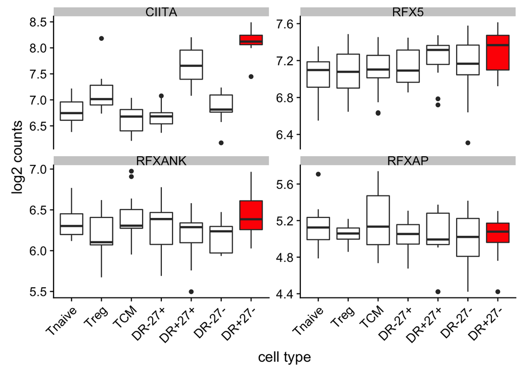

```r
tfs.potential <- subset(tf.enrich, q.val < .01)$geneset
plot.markers(exprs.kallisto.counts, tfs.potential)
```

The targets of CIITA are shown in the heatmap below.

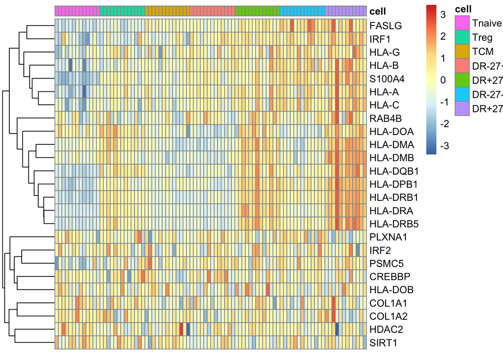

```r
anno.col.df <- metadata %>%
  dplyr::filter(Position %in% colnames(exprs.kallisto.counts)) %>%
  dplyr::mutate(cell = factor(cell, levels = cell.levels)) %>%
  dplyr::arrange(cell)
row.names(anno.col.df) <- anno.col.df$Position

ciita.targets <- intersect(tftargets::TRRUST$CIITA, row.names(exprs.kallisto.counts))

exprs.kallisto.counts[ciita.targets, anno.col.df$Position] %>%
  pheatmap(labels_col = rep("", 90),
           annotation_col = anno.col.df[, "cell", drop = F],
           cluster_cols = F, cluster_rows = T, scale = "row")
```

## DR+/27- vs groups

### C2: curated pathways

```r
wb.gage <- createWorkbook()
gs <- MSigDB::MSigDB$C2_CURATED[grep("KEGG|PID|REACTOME|BIOCARTA", names(MSigDB::MSigDB$C2_CURATED))]
for (other.group in names(groups.to.compare)) {
  addWorksheet(wb.gage, other.group)

  ## Gage Pathway Enrichment
  limma.res <- read.xlsx("../results/DiffExp.xlsx", sheet = other.group)
  gage.res <- limma.res %>% dplyr::rename(symbol = feature) %>% do.gage(gs, "t") %>%
    tidyr::separate(geneset, c("source", "pathway"), sep = "_", extra = "merge")

  writeDataTable(wb.gage, other.group, gage.res)

  saveWorkbook(wb.gage, file = "../results/gage_c2.xlsx", overwrite = TRUE)
}
```

### C7: immunological signatures

I found 30 signatures (paired: 15 up, 15 down) of genes in msigdb that are related either to Th1 vs Th17 experiments or CD4 vs NK experiments.

```r
c7.names <- names(MSigDB::MSigDB$C7_IMMUNOLOGIC_SIGNATURES)
c7.th1.th17 <- c7.names[grep("Th1_vs_Th17", c7.names, ignore.case = T)]
c7.cd4.nk <- c7.names[grep("CD4.*_vs_NK", c7.names, ignore.case = T)]
gs.immuno <- MSigDB::MSigDB$C7_IMMUNOLOGIC_SIGNATURES[c(c7.th1.th17, c7.cd4.nk)]

wb.gage <- createWorkbook()
gage.res.c7 <- data.frame()
for (other.group in names(groups.to.compare)) {
  addWorksheet(wb.gage, other.group)
  limma.res <- read.xlsx("../results/DiffExp.xlsx", sheet = other.group)
  gage.res <- limma.res %>% dplyr::rename(symbol = feature) %>% do.gage(gs.immuno, "t") %>%
    tidyr::separate(geneset, c("source", "pathway"), sep = "_", extra = "merge") %>%
    dplyr::arrange(q.val, direction)
  gage.res.c7 %<>% rbind(gage.res %>% dplyr::mutate(comparison = other.group))
  writeDataTable(wb.gage, other.group, gage.res)
}
```

```
## [1] "doing gage on 30 sets"
## [1] "doing gage on 30 sets"
## [1] "doing gage on 30 sets"
## [1] "doing gage on 30 sets"
## [1] "doing gage on 30 sets"
## [1] "doing gage on 30 sets"
## [1] "doing gage on 30 sets"
## [1] "doing gage on 30 sets"
## [1] "doing gage on 30 sets"
```

```r
saveWorkbook(wb.gage, file = "../results/gage_c7.xlsx", overwrite = TRUE)
```

```r
gage.res.c7 %>%
  subset(comparison == "DRp27p") %>%
  dplyr::filter(q.val < .01) %>%
  dplyr::select(source, pathway, q.val, direction)
```

```
##     source                                             pathway
## 1 GSE26030  TH1_VS_TH17_RESTIMULATED_DAY5_POST_POLARIZATION_UP
## 2 GSE22886                        NAIVE_CD4_TCELL_VS_NKCELL_UP
## 3 GSE26030 TH1_VS_TH17_RESTIMULATED_DAY15_POST_POLARIZATION_DN
## 4 GSE22886                        NAIVE_CD4_TCELL_VS_NKCELL_DN
## 5 GSE26030              TH1_VS_TH17_DAY15_POST_POLARIZATION_DN
## 6 GSE27786                              CD4_TCELL_VS_NKCELL_DN
##          q.val direction
## 1 2.569193e-08   greater
## 2 6.822430e-08      less
## 3 2.298175e-06   greater
## 4 1.404084e-03   greater
## 5 3.944819e-03   greater
## 6 9.185513e-03   greater
```

```r
limma.res.all %>% subset(other.group == "DRp27p") %>%
  dplyr::filter(feature %in% gs.immuno[["GSE26030_TH1_VS_TH17_RESTIMULATED_DAY5_POST_POLARIZATION_UP"]]) %>%
  dplyr::arrange(-t) %>% head(10)
```

```
##    feature     logFC   AveExpr        t      P.Value   adj.P.Val
## 1   LGALS1 1.2763134  6.995633 5.525389 4.584530e-06 0.001790788
## 2   S100A6 0.8500017  8.026353 4.666210 5.444272e-05 0.009424777
## 3     CD52 0.7888130  9.796343 3.972657 3.880373e-04 0.036946001
## 4   RABAC1 0.4381389  7.746846 3.598129 1.087576e-03 0.070628342
## 5      VIM 0.4667123 12.064478 3.164007 3.446929e-03 0.140269493
## 6   SEC61G 0.3000752  5.831806 3.021084 4.978574e-03 0.166689238
## 7     EMP3 0.3519339  7.653143 2.989899 5.389541e-03 0.177774058
## 8    ITGAM 0.4246393  5.563493 2.848679 7.685319e-03 0.214673485
## 9  BLOC1S1 0.3250922  6.366919 2.720221 1.054432e-02 0.252481757
## 10   SNRPF 0.2107391  5.770664 2.639270 1.282639e-02 0.283679084
##              B other.group
## 1   4.17889767      DRp27p
## 2   1.88345950      DRp27p
## 3   0.06696701      DRp27p
## 4  -0.87991720      DRp27p
## 5  -1.93008646      DRp27p
## 6  -2.26173824      DRp27p
## 7  -2.33304437      DRp27p
## 8  -2.65087320      DRp27p
## 9  -2.93232259      DRp27p
## 10 -3.10568001      DRp27p
```

```r
limma.res.all %>% subset(other.group == "DRp27p") %>%
  dplyr::filter(feature %in% gs.immuno[["GSE26030_TH1_VS_TH17_RESTIMULATED_DAY5_POST_POLARIZATION_DN"]]) %>%
  dplyr::arrange(-t) %>% head(10)
```

```
##      feature     logFC  AveExpr        t      P.Value   adj.P.Val
## 1      HIPK2 0.5170697 7.949995 5.107901 1.528327e-05 0.004084654
## 2        ID2 0.7228437 7.829874 3.743970 7.304866e-04 0.055620522
## 3      GTDC1 0.2966026 7.210468 3.520437 1.341800e-03 0.081115034
## 4        TXN 0.4303250 6.482631 3.300018 2.414914e-03 0.114606853
## 5  RAB11FIP5 0.3711518 5.402657 2.594626 1.427317e-02 0.297395739
## 6     CHST11 0.2709264 6.672124 2.503119 1.772098e-02 0.329934458
## 7      CENPO 0.2640820 5.567718 2.238919 3.238891e-02 0.422442376
## 8      ADCY9 0.2328360 6.077006 2.096937 4.415263e-02 0.477235849
## 9    SLC36A1 0.1908399 6.005152 1.865855 7.143613e-02 0.561642625
## 10   TMEM164 0.2193250 6.182766 1.791115 8.292824e-02 0.589789386
##             B other.group
## 1   3.0619804      DRp27p
## 2  -0.5150113      DRp27p
## 3  -1.0720528      DRp27p
## 4  -1.6075464      DRp27p
## 5  -3.1999000      DRp27p
## 6  -3.3898211      DRp27p
## 7  -3.9123602      DRp27p
## 8  -4.1760602      DRp27p
## 9  -4.5772176      DRp27p
## 10 -4.6990884      DRp27p
```